# Final Exam

STAT 353

Zeqiu Yu

May 12, 2023

# An Overview of the Problem

In the United States, gun violence in K-12 schools has grown rapidly over the past two decades. For example, the mass shooting at Uvalde Elementary in Texas (2022) received a large degree of media attention. While the scale of this event was extreme, however, gun violence of smaller scales is more [common](https://news.google.com/search?q=gun%20school&hl=en-US&gl=US&ceid=US%3Aen) .

As gun violence increases, researchers and policymakers continue to search for solutions. These include ideas like increasing monitoring of social and mental health of students, using metal detectors, stationing police in schools, among others. This question - What can we do to reduce gun violence? - provides the background for this exam.

## The SSOCS Data

“The School Survey on Crime and Safety (SSOCS) — a nationally representative survey of U.S. K–12 public schools — is managed by the National Center for Education Statistics (NCES), an agency within the U.S. Department of Education’s Institute of Education Sciences. SSOCS collects detailed information from public schools on the incidence, frequency, seriousness, and nature of violence affecting students and school personnel. SSOCS also collects information on the programs, practices, and policies that schools have in place to prevent and reduce crime. Data from this collection can be used to examine the relationship between school characteristics and violent crimes in regular public primary, middle, high, and combined schools.”

All of the information that you need to understand this data is provided. This includes:

- `SSOCS(2017-2018)Data.csv` : The data
- `ssocs codebook.pdf` : The code book

Notice that in the code book, the `Appendix A` includes the actual survey and that `Appendix B` includes a list of all the variable names and definitions. Further information on the creation of composite variables (those ending in “18”) can be found in `Chapter 5`.

(Throughout, pay particular attention to data with values of “-1”. These are purposeful skips and in many (but not all) cases may need to be re-coded to “0”.)

## This Exam

The purpose of this exam is to test your ability to put to use all that you have learned in STAT 353 in the context of real data, with a real question. This involves combining your understanding of regression concepts and theory with the implementation of these in code and clear interpretation to a lay audience. Be sure to convey what the results tell you, what assumptions they require, and any limitations in your results.

For this exam, we will focus in particular on two outcomes:

- `INCID18` : total incidents of any crime
- `DISFIRE18` : total use of firearm or explosive

To simply the analysis, you can ignore the sampling weights / jackknife replicates.

**Finally, a strong exam is one that is judicious in what is presented (you can put materials in an Appendix), that explains the decisions and assumptions that were made and why, that explains the how the results should be interpreted, and that is clear in any limitations.**

# Part I. Testing Hypotheses

As stated above, researchers and policymakers have hypothesized and enacted a variety of policies meant to reduce crimes and gun violence in schools. In particular, they often argue that schools should include *security guards* in order to reduce crime and gun violence.

For this part, answer the following questions:

1. After exploring the two outcomes (`INCID18` and `DISFIRE18`) determine what type of regression model is appropriate for each (e.g., OLS). Explain which is best and why.

Before the analysis, having a look at the distribution of the dataset is necessary.

```
## [1] "INCID18:  "
```

```
##    Min. 1st Qu.  Median    Mean 3rd Qu.    Max.
##     0.0     5.0    15.0    28.2    35.0   376.0
```

```
## [1] "The mean of INCID18: 28.197 and the variance of INCID18: 1576.841"
```

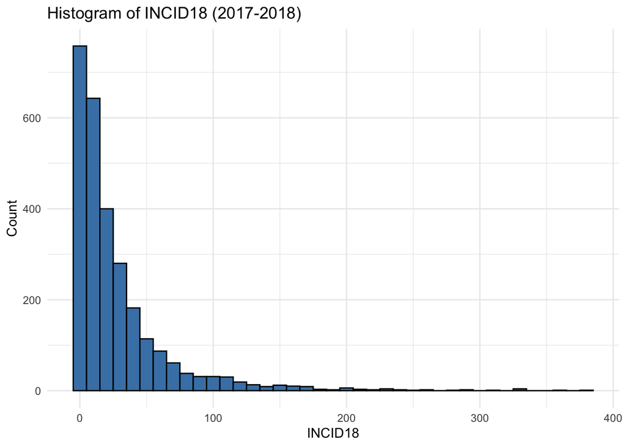

```
## [1] "DISFIRE18:  "
```

```
##     Min.  1st Qu.   Median     Mean  3rd Qu.     Max.
##  0.00000  0.00000  0.00000  0.09848  0.00000 81.00000
```

```
## [1] "The mean of DISFIRE18: 0.098 and the variance of DISFIRE18: 2.515"
```

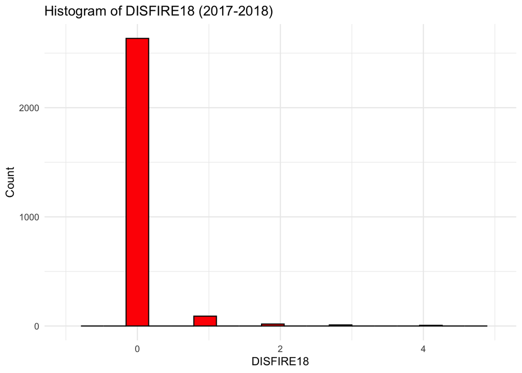

The outcome variable `INCID18` is a variable that counts the total number of incidents of crime or violence that occurred at a school during the 2017-2018 school year, and the outcome variable `DISFIRE18` indicates total use of firearm or explosive during the 2017-2018 school year. Considering `INCID18` is a nonnegative discrete variable(count data) that measures the frequency. Under this circumstance, a Poisson regression or a binomial regression tend to be better than OLS. Also, considering the assumption of the OLS that the error term should be normally distributed, the histograms of these two variables are severly skewed right. Under this circumstance, OLS is not a good model for these two variables.

Above all, I will not consider OLS for both variables and prefer using NB regression to using Poisson regression for `INCID18`. I think NB regression and Poisson regression may all work well for `INCID18`. However, dispersion test will also be conducted to decide the use of NB regression or Poisson regression.

2. Are the presence of *security guards* (`SEC_FT18` and `SEC_PT18`) associated with reductions in crime (`INCID18`) and gun violence (`DISFIRE18`)? Interpret the effects clearly in language that a non-statistician could understand.  
   Conduct dispersion test first to decide the use of Poisson regression

```
## [1] 37.11913
```

```
## [1] 0.7906956
```

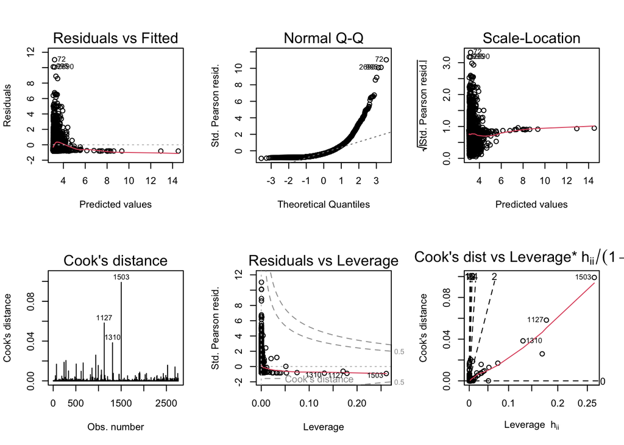

From the plot, I can find 1127, 1310 and 1503 are outliers. After removing them, I get following results:

```
##
## Call:
## glm.nb(formula = INCID18 ~ SEC_FT18 + SEC_PT18, data = new_data_1,
##     init.theta = 0.6648927854, link = log)
##
## Deviance Residuals:
##     Min       1Q   Median       3Q      Max
## -3.7552  -1.0469  -0.4049   0.2074   3.8447
##
## Coefficients:
##             Estimate Std. Error z value Pr(>|z|)
## (Intercept) 3.037581   0.027577 110.147  < 2e-16 ***
## SEC_FT18    0.140367   0.006845  20.507  < 2e-16 ***
## SEC_PT18    0.040070   0.013272   3.019  0.00254 **
## ---
## Signif. codes:  0 '***' 0.001 '**' 0.01 '*' 0.05 '.' 0.1 ' ' 1
##
## (Dispersion parameter for Negative Binomial(0.6649) family taken to be 1)
##
##     Null deviance: 3479.5  on 2758  degrees of freedom
## Residual deviance: 3281.6  on 2756  degrees of freedom
## AIC: 23493
##
## Number of Fisher Scoring iterations: 1
##
##
##               Theta:  0.6649
##           Std. Err.:  0.0174
##
##  2 x log-likelihood:  -23484.8750
```

`DISFIRE18` with Poisson regression:  
**Likewise, I use `The poisson model` here. Then I focus on the outcome `DISFIRE18`:**

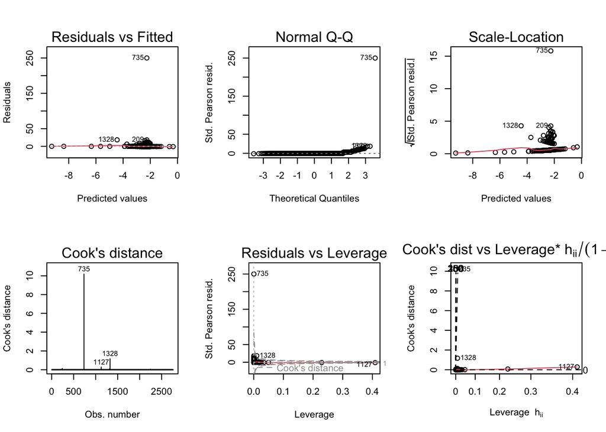

Similarly, I find 735, 1127 and 1328 are outliers, after removing them, I get following results:

```
##
## Call:
## glm(formula = DISFIRE18 ~ SEC_FT18 + SEC_PT18, family = "poisson",
##     data = new_data_2)
##
## Deviance Residuals:
##     Min       1Q   Median       3Q      Max
## -1.3952  -0.4693  -0.4629  -0.4023  30.1245
##
## Coefficients:
##              Estimate Std. Error z value Pr(>|z|)
## (Intercept) -2.233551   0.070686 -31.598  < 2e-16 ***
## SEC_FT18     0.027580   0.009025   3.056 0.002243 **
## SEC_PT18    -0.280810   0.076965  -3.649 0.000264 ***
## ---
## Signif. codes:  0 '***' 0.001 '**' 0.01 '*' 0.05 '.' 0.1 ' ' 1
##
## (Dispersion parameter for poisson family taken to be 1)
##
##     Null deviance: 2184.2  on 2758  degrees of freedom
## Residual deviance: 2158.6  on 2756  degrees of freedom
## AIC: 2451.9
##
## Number of Fisher Scoring iterations: 7
```

Above all, after conducting dispersion test, I decide to use Negative Binomial regression to `INCID18` and Poisson regression to `DISFIRE18`, it is the same as the conclusion from the last question.

3. To what extent do these effects differ in urban schools versus non-urban schools?  
   According to the decription of the variables, I first transform the values of `FR_URBAN`, using 1 to denote that the schools are in urban areas and 0 to denote that the schools are in non-urban areas. After doing that, involve it into the model and do dispersion test again to check which kind models should i implement.

```
## [1] "Poisson dispersion test:"
```

```
## [1] 45.91349
```

```
## [1] 32.44051
```

```
## [1] 0.4771707
```

```
## [1] 0.8874234
```

From the result, I find we can still use the model we used before. The dispersion of `INCID18` is large for both urban and non-urban data and then we still choose Negative Binomial regression and considering the dispersion of `DISFIRE18` for both data, we decide to keep using Poisson regression.  
For the versus on `INCID18`:

```
##
## Call:
## glm.nb(formula = INCID18 ~ SEC_FT18 + SEC_PT18, data = new_data_urban1,
##     init.theta = 0.6192014379, link = log)
##
## Deviance Residuals:
##     Min       1Q   Median       3Q      Max
## -2.5183  -1.1333  -0.4649   0.2241   2.9641
##
## Coefficients:
##             Estimate Std. Error z value Pr(>|z|)
## (Intercept) 3.327969   0.059165  56.249  < 2e-16 ***
## SEC_FT18    0.108957   0.015428   7.062 1.64e-12 ***
## SEC_PT18    0.008432   0.027675   0.305    0.761
## ---
## Signif. codes:  0 '***' 0.001 '**' 0.01 '*' 0.05 '.' 0.1 ' ' 1
##
## (Dispersion parameter for Negative Binomial(0.6192) family taken to be 1)
##
##     Null deviance: 895.96  on 721  degrees of freedom
## Residual deviance: 864.88  on 719  degrees of freedom
## AIC: 6489.8
##
## Number of Fisher Scoring iterations: 1
##
##
##               Theta:  0.6192
##           Std. Err.:  0.0310
##
##  2 x log-likelihood:  -6481.7740
```

```
##
## Call:
## glm.nb(formula = INCID18 ~ SEC_FT18 + SEC_PT18, data = new_data_non1,
##     init.theta = 0.6955747296, link = log)
##
## Deviance Residuals:
##     Min       1Q   Median       3Q      Max
## -3.8597  -1.0218  -0.3780   0.2196   4.1808
##
## Coefficients:
##             Estimate Std. Error z value Pr(>|z|)
## (Intercept) 2.931054   0.031009   94.52  < 2e-16 ***
## SEC_FT18    0.145382   0.007561   19.23  < 2e-16 ***
## SEC_PT18    0.055098   0.014973    3.68 0.000233 ***
## ---
## Signif. codes:  0 '***' 0.001 '**' 0.01 '*' 0.05 '.' 0.1 ' ' 1
##
## (Dispersion parameter for Negative Binomial(0.6956) family taken to be 1)
##
##     Null deviance: 2581.6  on 2036  degrees of freedom
## Residual deviance: 2415.8  on 2034  degrees of freedom
## AIC: 16970
##
## Number of Fisher Scoring iterations: 1
##
##
##               Theta:  0.6956
##           Std. Err.:  0.0215
##
##  2 x log-likelihood:  -16962.3740
```

```
##
## Call:
## glm.nb(formula = INCID18 ~ SEC_FT18, data = new_data_urban1,
##     init.theta = 0.6191488297, link = log)
##
## Deviance Residuals:
##     Min       1Q   Median       3Q      Max
## -2.5188  -1.1331  -0.4672   0.2263   2.9525
##
## Coefficients:
##             Estimate Std. Error z value Pr(>|z|)
## (Intercept)  3.33387    0.05637  59.141  < 2e-16 ***
## SEC_FT18     0.10868    0.01543   7.045 1.85e-12 ***
## ---
## Signif. codes:  0 '***' 0.001 '**' 0.01 '*' 0.05 '.' 0.1 ' ' 1
##
## (Dispersion parameter for Negative Binomial(0.6191) family taken to be 1)
##
##     Null deviance: 895.89  on 721  degrees of freedom
## Residual deviance: 864.89  on 720  degrees of freedom
## AIC: 6487.8
##
## Number of Fisher Scoring iterations: 1
##
##
##               Theta:  0.6191
##           Std. Err.:  0.0310
##
##  2 x log-likelihood:  -6481.8460
```

```
## Calls:
## 1: glm.nb(formula = INCID18 ~ SEC_FT18 + SEC_PT18, data = new_data_urban1,
##   init.theta = 0.6192014379, link = log)
## 2: glm.nb(formula = INCID18 ~ SEC_FT18, data = new_data_urban1, init.theta =
##    0.6191488297, link = log)
## 3: glm.nb(formula = INCID18 ~ SEC_FT18 + SEC_PT18, data = new_data_non1,
##   init.theta = 0.6955747296, link = log)
##
##             Model 1 Model 2 Model 3
## (Intercept)  3.3280  3.3339  2.9311
## SE           0.0592  0.0564  0.0310
##
## SEC_FT18    0.10896 0.10868 0.14538
## SE          0.01543 0.01543 0.00756
##
## SEC_PT18    0.00843         0.05510
## SE          0.02767         0.01497
##
```

Refer to the summary table of the urban data, `SEC_PT` at the 0.05 level, this effect even should not be involved in the model. According to the comparing results, we can find that no matter `SEC_PT18` is considered or not, the coefficients for `SEC_FT18` and `SEC_PT18` of the urban area are all much smaller than the non-urban area, which means the presence of full-time and part-time security guards in non-urban schools have more effects on `INCID18` than the the schools in urban area.

For the versus on `DISFIRE18`

```
##
## Call:
## glm(formula = DISFIRE18 ~ SEC_FT18 + SEC_PT18, family = "poisson",
##     data = new_data_urban2)
##
## Deviance Residuals:
##     Min       1Q   Median       3Q      Max
## -1.3396  -0.4001  -0.3710  -0.3604   6.3922
##
## Coefficients:
##             Estimate Std. Error z value Pr(>|z|)
## (Intercept) -2.67642    0.16633 -16.091  < 2e-16 ***
## SEC_FT18     0.07553    0.02356   3.205  0.00135 **
## SEC_PT18    -0.13348    0.14285  -0.934  0.35009
## ---
## Signif. codes:  0 '***' 0.001 '**' 0.01 '*' 0.05 '.' 0.1 ' ' 1
##
## (Dispersion parameter for poisson family taken to be 1)
##
##     Null deviance: 350.70  on 720  degrees of freedom
## Residual deviance: 342.61  on 718  degrees of freedom
## AIC: 432.73
##
## Number of Fisher Scoring iterations: 7
```

```
##              Estimate Std. Error  z value  Pr(>|z|)
## (Intercept) -2.744752   0.154623 -17.7513 < 2.2e-16
## SEC_FT18     0.076570   0.023674   3.2343  0.001219
##
## n = 721 p = 2
## Deviance = 343.73795 Null Deviance = 350.69553 (Difference = 6.95759)
```

```
##
## Call:
## glm(formula = DISFIRE18 ~ SEC_FT18 + SEC_PT18, family = "poisson",
##     data = new_data_non2)
##
## Deviance Residuals:
##     Min       1Q   Median       3Q      Max
## -1.1819  -0.4953  -0.4899  -0.4146  29.8342
##
## Coefficients:
##             Estimate Std. Error z value Pr(>|z|)
## (Intercept) -2.12036    0.07922 -26.765  < 2e-16 ***
## SEC_FT18     0.02202    0.01050   2.096 0.036072 *
## SEC_PT18    -0.33382    0.09093  -3.671 0.000241 ***
## ---
## Signif. codes:  0 '***' 0.001 '**' 0.01 '*' 0.05 '.' 0.1 ' ' 1
##
## (Dispersion parameter for poisson family taken to be 1)
##
##     Null deviance: 1829.2  on 2037  degrees of freedom
## Residual deviance: 1805.9  on 2035  degrees of freedom
## AIC: 2015.1
##
## Number of Fisher Scoring iterations: 7
```

```
## Calls:
## 1: glm(formula = DISFIRE18 ~ SEC_FT18 + SEC_PT18, family = "poisson", data =
##    new_data_urban2)
## 2: glm(formula = DISFIRE18 ~ SEC_FT18, family = "poisson", data =
##   new_data_urban2)
## 3: glm(formula = DISFIRE18 ~ SEC_FT18 + SEC_PT18, family = "poisson", data =
##    new_data_non2)
##
##             Model 1 Model 2 Model 3
## (Intercept) -2.6764 -2.7448 -2.1204
## SE           0.1663  0.1546  0.0792
##
## SEC_FT18     0.0755  0.0766  0.0220
## SE           0.0236  0.0237  0.0105
##
## SEC_PT18    -0.1335         -0.3338
## SE           0.1428          0.0909
##
```

Similarly, do the same analysis, we find we may also want to drop `SEC_PT18` in the model of urban data for the level of 0.05. According to the comparing results, we can find that no matter `SEC_PT18` is considered or not, the absolute value of coefficients for `SEC_FT18` has larger effect on `DISFIRE18` for the schools in the urban area and `SEC_PT18` has larger effect on `DISFIRE18` for the schools in the non-urban area.

4. Do your analyses suggest that policymakers are correct that security guards reduce crime and gun violence? If so, explain why. If not, conduct additional analyses (using regression) that allow you to evaluate their claim and interpret your results.

```
##
## Call:
## glm.nb(formula = INCID18 ~ SEC_FT18 + SEC_PT18, data = new_data_1,
##     init.theta = 0.6648927854, link = log)
##
## Deviance Residuals:
##     Min       1Q   Median       3Q      Max
## -3.7552  -1.0469  -0.4049   0.2074   3.8447
##
## Coefficients:
##             Estimate Std. Error z value Pr(>|z|)
## (Intercept) 3.037581   0.027577 110.147  < 2e-16 ***
## SEC_FT18    0.140367   0.006845  20.507  < 2e-16 ***
## SEC_PT18    0.040070   0.013272   3.019  0.00254 **
## ---
## Signif. codes:  0 '***' 0.001 '**' 0.01 '*' 0.05 '.' 0.1 ' ' 1
##
## (Dispersion parameter for Negative Binomial(0.6649) family taken to be 1)
##
##     Null deviance: 3479.5  on 2758  degrees of freedom
## Residual deviance: 3281.6  on 2756  degrees of freedom
## AIC: 23493
##
## Number of Fisher Scoring iterations: 1
##
##
##               Theta:  0.6649
##           Std. Err.:  0.0174
##
##  2 x log-likelihood:  -23484.8750
```

```
##
## Call:
## glm(formula = DISFIRE18 ~ SEC_FT18 + SEC_PT18, family = "poisson",
##     data = new_data_2)
##
## Deviance Residuals:
##     Min       1Q   Median       3Q      Max
## -1.3952  -0.4693  -0.4629  -0.4023  30.1245
##
## Coefficients:
##              Estimate Std. Error z value Pr(>|z|)
## (Intercept) -2.233551   0.070686 -31.598  < 2e-16 ***
## SEC_FT18     0.027580   0.009025   3.056 0.002243 **
## SEC_PT18    -0.280810   0.076965  -3.649 0.000264 ***
## ---
## Signif. codes:  0 '***' 0.001 '**' 0.01 '*' 0.05 '.' 0.1 ' ' 1
##
## (Dispersion parameter for poisson family taken to be 1)
##
##     Null deviance: 2184.2  on 2758  degrees of freedom
## Residual deviance: 2158.6  on 2756  degrees of freedom
## AIC: 2451.9
##
## Number of Fisher Scoring iterations: 7
```

```
##
## Call:
## glm(formula = DISFIRE18 ~ SEC_FT18 + SEC_PT18, family = "poisson",
##     data = nodetector)
##
## Deviance Residuals:
##     Min       1Q   Median       3Q      Max
## -1.2247  -0.4655  -0.4599  -0.3885  30.1683
##
## Coefficients:
##             Estimate Std. Error z value Pr(>|z|)
## (Intercept) -2.24676    0.07465 -30.097  < 2e-16 ***
## SEC_FT18     0.02449    0.01051   2.331  0.01977 *
## SEC_PT18    -0.33748    0.08938  -3.776  0.00016 ***
## ---
## Signif. codes:  0 '***' 0.001 '**' 0.01 '*' 0.05 '.' 0.1 ' ' 1
##
## (Dispersion parameter for poisson family taken to be 1)
##
##     Null deviance: 2036.2  on 2548  degrees of freedom
## Residual deviance: 2011.3  on 2546  degrees of freedom
## AIC: 2254.2
##
## Number of Fisher Scoring iterations: 7
```

# Part II. Predicting Crime

Other researchers and policymakers would like to develop a model to predict crime (`INCID18`) based upon observable school characteristics. Their idea is that they could first predict schools that have a lot of crime and then put in place interventions that could reduce such crime.

For this part, perform the following tasks.

1. For your first model, use variables `C0532`, `C0534`, `C0536`, `C0538`, `C0560`, `C0562`, `C0568`, `FR_LVEL`, `FR_URBAN`, and `FR_SIZE` as predictor variables. Be sure to pay attention to non-linearities and interactions. (In addition to Appendix B, you can find more detailed explanation for the variables `C0532` to `C0568` on pages 80-81 of the code book, and the three variables `FR_LVEL`, `FR_URBAN`, and `FR_SIZE` on page 172). How well does this model perform?

Firstly, I want to figure out Poisson and NB regressions, which one is more appropriate.

[output not shown]

```
## [1] "According to the dispersion test, I prefer to use NB regression for the model."
```

First give a base model as follows:

```
##
## Call:
## glm.nb(formula = INCID18 ~ C0532 + C0534 + C0536 + C0538 + C0560 +
##     C0562 + C0568 + FR_LVEL + FR_URBAN + FR_SIZE, data = data,
##     init.theta = 0.870028887, link = log)
##
## Deviance Residuals:
##     Min       1Q   Median       3Q      Max
## -2.9071  -1.0012  -0.3730   0.2375   5.1309
##
## Coefficients:
##               Estimate Std. Error z value Pr(>|z|)
## (Intercept)  2.1436265  0.3044649   7.041 1.91e-12 ***
## C0532        0.0076216  0.0013674   5.574 2.49e-08 ***
## C0534       -0.0033694  0.0012361  -2.726 0.006411 **
## C0536       -0.0061397  0.0013126  -4.678 2.90e-06 ***
## C0538        0.0790182  0.0095209   8.299  < 2e-16 ***
## C0560       -0.0728909  0.0345555  -2.109 0.034911 *
## C0562       -0.2495463  0.0484126  -5.155 2.54e-07 ***
## C0568       -0.0002826  0.0028299  -0.100 0.920441
## FR_LVEL      0.2027681  0.0273538   7.413 1.24e-13 ***
## FR_URBAN    -0.0845011  0.0221043  -3.823 0.000132 ***
## FR_SIZE      0.5689275  0.0245323  23.191  < 2e-16 ***
## ---
## Signif. codes:  0 '***' 0.001 '**' 0.01 '*' 0.05 '.' 0.1 ' ' 1
##
## (Dispersion parameter for Negative Binomial(0.87) family taken to be 1)
##
##     Null deviance: 4392.6  on 2761  degrees of freedom
## Residual deviance: 3256.2  on 2751  degrees of freedom
## AIC: 22767
##
## Number of Fisher Scoring iterations: 1
##
##
##               Theta:  0.8700
##           Std. Err.:  0.0241
##
##  2 x log-likelihood:  -22743.0550
```

After conducting some trials, I get a relatively better model as follows

```
##
## Call:
## glm.nb(formula = INCID18 ~ C0532 + C0534 + C0536 + C0538 + C0560 +
##     C0562 + C0568 + FR_LVEL + FR_URBAN + FR_SIZE + C0560:FR_LVEL +
##     I(C0532^2) + I(C0538^2) + I(C0560^2) + I(FR_LVEL^2), data = data,
##     init.theta = 0.9303251577, link = log)
##
## Deviance Residuals:
##     Min       1Q   Median       3Q      Max
## -2.8872  -0.9813  -0.3870   0.2441   5.8388
##
## Coefficients:
##                 Estimate Std. Error z value Pr(>|z|)
## (Intercept)    2.2770241  0.3872464   5.880 4.10e-09 ***
## C0532          0.0181799  0.0035299   5.150 2.60e-07 ***
## C0534         -0.0022230  0.0012056  -1.844  0.06520 .
## C0536         -0.0056287  0.0012774  -4.406 1.05e-05 ***
## C0538          0.1188710  0.0279758   4.249 2.15e-05 ***
## C0560         -1.1258775  0.1786826  -6.301 2.96e-10 ***
## C0562         -0.1208318  0.0532048  -2.271  0.02314 *
## C0568         -0.0027395  0.0027428  -0.999  0.31789
## FR_LVEL        1.3176642  0.1584706   8.315  < 2e-16 ***
## FR_URBAN      -0.0590692  0.0216190  -2.732  0.00629 **
## FR_SIZE        0.5357121  0.0241779  22.157  < 2e-16 ***
## I(C0532^2)    -0.0001492  0.0000454  -3.286  0.00102 **
## I(C0538^2)    -0.0061835  0.0022512  -2.747  0.00602 **
## I(C0560^2)     0.1237262  0.0292345   4.232 2.31e-05 ***
## I(FR_LVEL^2)  -0.3511351  0.0293116 -11.979  < 2e-16 ***
## C0560:FR_LVEL  0.1558820  0.0306158   5.092 3.55e-07 ***
## ---
## Signif. codes:  0 '***' 0.001 '**' 0.01 '*' 0.05 '.' 0.1 ' ' 1
##
## (Dispersion parameter for Negative Binomial(0.9303) family taken to be 1)
##
##     Null deviance: 4652.7  on 2761  degrees of freedom
## Residual deviance: 3250.4  on 2746  degrees of freedom
## AIC: 22592
##
## Number of Fisher Scoring iterations: 1
##
##
##               Theta:  0.9303
##           Std. Err.:  0.0261
##
##  2 x log-likelihood:  -22558.1150
```

To evaluate it, I apply RMSE and MAE to the model I choose and the base model and compare the results.

```
## [1] "Base model:  "
```

```
## [1] "RMSE:  "
```

```
## [1] 36.01762
```

```
## [1] "MAE"
```

```
## [1] 21.0154
```

```
## [1] "Target model:  "
```

```
## [1] "RMSE:  "
```

```
## [1] 35.10357
```

```
## [1] "MAE"
```

```
## [1] 20.29186
```

We can find that the mode I choose is much better, it has smaller RMSE and MAE in comparison with the previous base model. Moreover, from the summary table, we can find the chosen model has smaller AIC value than the previous one. Hence, the model is improved.  
2. Create a new model that includes only those covariates that were statistically significant in (1), further refining this until all covariates in this model are statistically significant. How well does this model perfrom relative to Model (1)?

We can find in the Model (1), `C0534` and `C0568` are not significant statistically, so we drop them out.

```
##
## Call:
## glm.nb(formula = INCID18 ~ C0532 + C0536 + C0538 + C0560 + C0562 +
##     FR_LVEL + FR_URBAN + FR_SIZE + C0560:FR_LVEL + I(C0532^2) +
##     I(C0538^2) + I(C0560^2) + I(FR_LVEL^2), data = data, init.theta = 0.9288977671,
##     link = log)
##
## Deviance Residuals:
##     Min       1Q   Median       3Q      Max
## -2.8956  -0.9888  -0.3774   0.2383   5.6215
##
## Coefficients:
##                 Estimate Std. Error z value Pr(>|z|)
## (Intercept)    1.994e+00  2.937e-01   6.790 1.12e-11 ***
## C0532          1.885e-02  3.492e-03   5.398 6.75e-08 ***
## C0536         -7.232e-03  1.004e-03  -7.203 5.89e-13 ***
## C0538          1.185e-01  2.797e-02   4.237 2.26e-05 ***
## C0560         -1.137e+00  1.787e-01  -6.365 1.95e-10 ***
## C0562         -1.240e-01  5.317e-02  -2.331 0.019735 *
## FR_LVEL        1.331e+00  1.585e-01   8.399  < 2e-16 ***
## FR_URBAN      -5.551e-02  2.139e-02  -2.595 0.009449 **
## FR_SIZE        5.345e-01  2.413e-02  22.157  < 2e-16 ***
## I(C0532^2)    -1.508e-04  4.526e-05  -3.331 0.000866 ***
## I(C0538^2)    -6.163e-03  2.251e-03  -2.738 0.006181 **
## I(C0560^2)     1.258e-01  2.924e-02   4.303 1.69e-05 ***
## I(FR_LVEL^2)  -3.532e-01  2.933e-02 -12.042  < 2e-16 ***
## C0560:FR_LVEL  1.548e-01  3.062e-02   5.057 4.26e-07 ***
## ---
## Signif. codes:  0 '***' 0.001 '**' 0.01 '*' 0.05 '.' 0.1 ' ' 1
##
## (Dispersion parameter for Negative Binomial(0.9289) family taken to be 1)
##
##     Null deviance: 4646.6  on 2761  degrees of freedom
## Residual deviance: 3250.3  on 2748  degrees of freedom
## AIC: 22592
##
## Number of Fisher Scoring iterations: 1
##
##
##               Theta:  0.9289
##           Std. Err.:  0.0261
##
##  2 x log-likelihood:  -22562.0540
```

We can find that after removing these two variables, all of the remaining variables are significant. Then evaluate it and compare it with the result of Model (1).

```
## [1] "Model (2) model:  "
```

```
## [1] "RMSE:  "
```

```
## [1] 35.14359
```

```
## [1] "MAE"
```

```
## [1] 20.32717
```

This model behaves not as well as Model (1) according to RMSE and MAE since they are all a slightly larger, but the variables it has are all statistically significant. The AIC value remains the same. However, in compare with the base model, There is still an improvement.

3. Develop and implement an approach to build the best model possible that predicts the total number of crimes (incidents, `INCID18`). (In addition to the variables mentioned in the previous problem, you may consider other variables, but be sure to explain your thinking.)

   What is your final model and why do you think it is the best? Be sure to clearly explain your approach in language a non-statistician could understand.

```
##
## Call:
## glm.nb(formula = INCID18 ~ C0532 + C0534 + C0536 + C0538 + C0560 +
##     C0562 + C0568 + FR_LVEL + FR_URBAN + FR_SIZE + C0560:FR_LVEL +
##     I(C0532^2) + I(C0538^2) + I(C0560^2) + I(FR_LVEL^2), data = data,
##     init.theta = 0.9303251577, link = log)
##
## Deviance Residuals:
##     Min       1Q   Median       3Q      Max
## -2.8872  -0.9813  -0.3870   0.2441   5.8388
##
## Coefficients:
##                 Estimate Std. Error z value Pr(>|z|)
## (Intercept)    2.2770241  0.3872464   5.880 4.10e-09 ***
## C0532          0.0181799  0.0035299   5.150 2.60e-07 ***
## C0534         -0.0022230  0.0012056  -1.844  0.06520 .
## C0536         -0.0056287  0.0012774  -4.406 1.05e-05 ***
## C0538          0.1188710  0.0279758   4.249 2.15e-05 ***
## C0560         -1.1258775  0.1786826  -6.301 2.96e-10 ***
## C0562         -0.1208318  0.0532048  -2.271  0.02314 *
## C0568         -0.0027395  0.0027428  -0.999  0.31789
## FR_LVEL        1.3176642  0.1584706   8.315  < 2e-16 ***
## FR_URBAN      -0.0590692  0.0216190  -2.732  0.00629 **
## FR_SIZE        0.5357121  0.0241779  22.157  < 2e-16 ***
## I(C0532^2)    -0.0001492  0.0000454  -3.286  0.00102 **
## I(C0538^2)    -0.0061835  0.0022512  -2.747  0.00602 **
## I(C0560^2)     0.1237262  0.0292345   4.232 2.31e-05 ***
## I(FR_LVEL^2)  -0.3511351  0.0293116 -11.979  < 2e-16 ***
## C0560:FR_LVEL  0.1558820  0.0306158   5.092 3.55e-07 ***
## ---
## Signif. codes:  0 '***' 0.001 '**' 0.01 '*' 0.05 '.' 0.1 ' ' 1
##
## (Dispersion parameter for Negative Binomial(0.9303) family taken to be 1)
##
##     Null deviance: 4652.7  on 2761  degrees of freedom
## Residual deviance: 3250.4  on 2746  degrees of freedom
## AIC: 22592
##
## Number of Fisher Scoring iterations: 1
##
##
##               Theta:  0.9303
##           Std. Err.:  0.0261
##
##  2 x log-likelihood:  -22558.1150
```

```
##
## Call:
## glm.nb(formula = INCID18 ~ FR_SIZE + C0562 + C0536 + C0538 +
##     C0532 + FR_LVEL + I(FR_LVEL^2) + I(C0532^2) + FR_URBAN +
##     C0560 + I(C0560^2) + I(C0538^2) + C0534 + FR_LVEL:C0560,
##     data = data, init.theta = 0.9300723763, link = log)
##
## Deviance Residuals:
##     Min       1Q   Median       3Q      Max
## -2.8967  -0.9818  -0.3850   0.2390   5.8566
##
## Coefficients:
##                 Estimate Std. Error z value Pr(>|z|)
## (Intercept)    2.0291542  0.2937556   6.908 4.93e-12 ***
## FR_SIZE        0.5341063  0.0241133  22.150  < 2e-16 ***
## C0562         -0.1207226  0.0532110  -2.269  0.02328 *
## C0536         -0.0057796  0.0012765  -4.528 5.97e-06 ***
## C0538          0.1175478  0.0279518   4.205 2.61e-05 ***
## C0532          0.0181703  0.0035280   5.150 2.60e-07 ***
## FR_LVEL        1.3230935  0.1583813   8.354  < 2e-16 ***
## I(FR_LVEL^2)  -0.3508167  0.0293123 -11.968  < 2e-16 ***
## I(C0532^2)    -0.0001471  0.0000454  -3.239  0.00120 **
## FR_URBAN      -0.0600423  0.0216004  -2.780  0.00544 **
## C0560         -1.1235704  0.1786984  -6.288 3.23e-10 ***
## I(C0560^2)     0.1237848  0.0292377   4.234 2.30e-05 ***
## I(C0538^2)    -0.0060923  0.0022495  -2.708  0.00676 **
## C0534         -0.0021983  0.0012053  -1.824  0.06816 .
## FR_LVEL:C0560  0.1544057  0.0306015   5.046 4.52e-07 ***
## ---
## Signif. codes:  0 '***' 0.001 '**' 0.01 '*' 0.05 '.' 0.1 ' ' 1
##
## (Dispersion parameter for Negative Binomial(0.9301) family taken to be 1)
##
##     Null deviance: 4651.7  on 2761  degrees of freedom
## Residual deviance: 3250.5  on 2747  degrees of freedom
## AIC: 22591
##
## Number of Fisher Scoring iterations: 1
##
##
##               Theta:  0.9301
##           Std. Err.:  0.0261
##
##  2 x log-likelihood:  -22558.9470
```

```
##                 df      AIC
## selected        16 22590.95
## modelUpper      17 22592.11
## nb_model_linear 12 22767.05
## modelLower       2 23709.00
```

```
##                 df      BIC
## selected        16 22685.73
## modelUpper      17 22692.82
## nb_model_linear 12 22838.14
## modelLower       2 23720.85
```

After testing several models with different combinations of predictor variables, nonlinearity terms, and interaction terms, I have selected a final model that can predict the total number of crimes (incidents) in schools using data from various variables.  
The final model includes the following variables:  
(1). Percentage of students who feel safe at school (C0534)  
(2). Percentage of students who participate in extracurricular activities (C0560)  
(3). Urbanicity of the school (FR_URBAN)  
(4). Nonlinearity term for percentage of students who below 15th percentile standardized tests (C0532^2)  
(4). Nonlinearity term for percentage of students who participate in extracurricular activities (C0560^2)  
(4). Nonlinearity term for number of classroom changes (C0538^2)  
(5). Interaction term between (C0560) and school level (FR_LVEL)

I keep employing a statistical technique known as negative binomial regression to construct the model. This method is suitable for count data, such as the total number of crimes in schools, and it addresses the problem of overdispersion, which occurs when the variance of count data is larger than the mean. For the last question, I use several methods and trials to find a relative much better model(I began by building an initial model that included all predictor variables. After that, I examined issues like multicollinearity and model assumptions and introduced nonlinearity and interaction terms to enhance the model’s fit and interpretation.). Accoriding to that and choose a base like INCID18~1, I use stepwise regression from both sides to find the best model.  
In compare with other models, the final model beats them with the lowest AIC and BIC scores. It is the best among these models.  
In summary, I consider the final model to be the best since it beats all other models according to a particular criterion called AIC and BIC scores. Additionally, the model is a good fit to the data, and the coefficients are interpretable in terms of their direction and size of influence on the outcome, which is the reason I keep using these variables.

4. Does your final model do a good job in predicting crime? Explain to a policymaker if and how they should properly use this model.

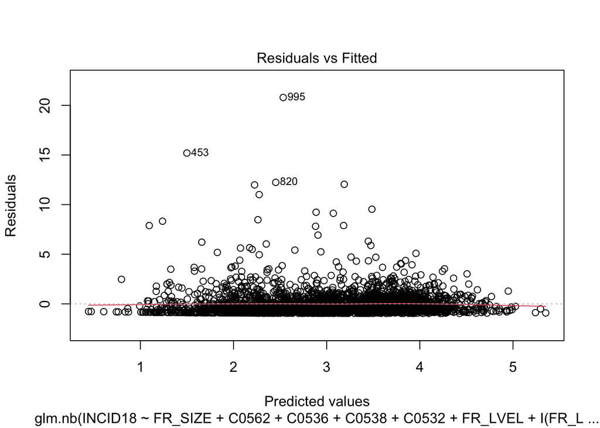

From the error plot of the final model, we can also find it fits well. After examining the data, I found that the final model I created performs well in predicting school crime. However, it is worth noting that no statistical model can provide absolute accuracy, and there may be unknown factors that affect crime rates in schools.

Despite this limitation, policymakers can use this model to identify the factors that contribute to school crime and assess the potential impact of interventions aimed at reducing it. By using the coefficients of the predictor variables, they can estimate how much impact measures like increased security or anti-bullying programs could have on reducing crime rates in schools.

Nevertheless, it is crucial to use the model with caution and not solely rely on it as the primary source of information. Policymakers should consider other pertinent factors, such as contextual factors and expert input, when making decisions.